# Informe QFD - Casa de la Calidad: Extractor de Aceite de Cannabis

Jonathan Sandro Terán Pabon

2025-08-02

# 1 Introducción

La Casa de la Calidad es una herramienta fundamental dentro del Despliegue de la Función de Calidad (QFD, por sus siglas en inglés). Su propósito es traducir los requerimientos del cliente (la voz del cliente) en especificaciones técnicas o ingenieriles que guíen el diseño y desarrollo del producto.

Se representa gráficamente como una matriz que relaciona “Qué se quiere” (requisitos del cliente) con “Cómo lograrlo” (características técnicas del producto). Esta matriz ayuda a priorizar las acciones de diseño y tomar decisiones fundamentadas en lo que realmente agrega valor desde la perspectiva del cliente.

# 2 Descripción de la matriz

La matriz principal contiene:

- Requisitos del cliente en filas (WHATs).
- Características técnicas del producto en columnas (HOWs).
- Relaciones entre ambos en la intersección, con símbolos o puntuaciones que indican la fuerza del vínculo.
- Peso de importancia por cada requerimiento.
- Dificultad de implementación de cada característica.
- Correlaciones entre los HOWs representadas en el “techo” de la casa.

## 2.1 Casa de calidad 1 (Requisitos del cliente vs Requisitos funcionales)

[figure not shown]

## 2.2 Casa de calidad 2 (Requisitos funcionales vs Atributos de producción)

Esta Casa actúa como un puente entre el “qué debe hacer el sistema” y el “cómo se va a lograr técnicamente”. Aquí se muestran los requerimientos técnicos en las filas como: Materiales, Automatización y Resistencia, que representan necesidades fundamentales de operación y durabilidad. Cualidades como Estabilidad química, Forma, Movilidad, Peso y Adaptabilidad del sistema, que definen cómo debe comportarse y adaptarse el diseño en diferentes condiciones. También se consideran aspectos como Capacidad de carga, si debe ser Multietapa, y si debe ser Desmontable. Por otro lado, se tiene los atributos o parámetros de diseño en las columnas que hacen posible cumplir los requisitos anteriores, como:

Uso de estructura de acero, integración de un sistema de PLCs, incorporación de software CAD y simulación, y el uso de solventes en el proceso. Variables geométricas y de diseño como forma cilíndrica, optimización geométrica del tornillo sinfín, y capacidades como potencia mecánica y cambio de velocidades. Cada intersección en la matriz está valorada para representar el nivel de relación o influencia entre cada requisito funcional y cada atributo técnico, lo que permite priorizar aquellos que son más factibles y de mayor impacto. A partir de allí, el diseño comienza a tomar forma en términos de requerimientos de manufactura, selección de componentes y tecnologías a utilizar.

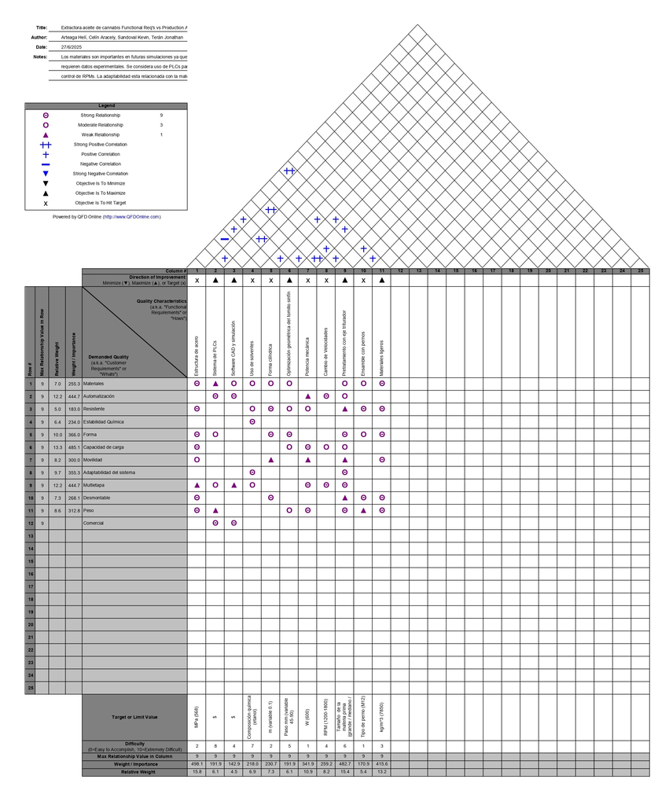

*Figura 2. Casa de calidad 2 (Requisitos funcionales vs Atributos de producción).*

## 2.3 Casa de calidad 3 (Atributos de producción vs Parametros de diseño)

En esta tercera Casa de Calidad se representa el nivel más técnico del análisis, en donde los atributos del proceso de producción se traducen en parámetros de diseño específicos. Esta matriz detalla variables como el diámetro óptimo de los ejes, la relación largodiámetro, el torque, o la compatibilidad química. Se identifican las conexiones entre estos parámetros y los requerimientos del proceso productivo, considerando también la dificultad técnica de lograr cada uno, lo cual permite tomar que decisiones impactan de forma más directa en el desempeño del prototipo. De esta manera, la matriz tiende a ser como una guía técnica que permite convertir un concepto en un prototipo funcional y confiable.

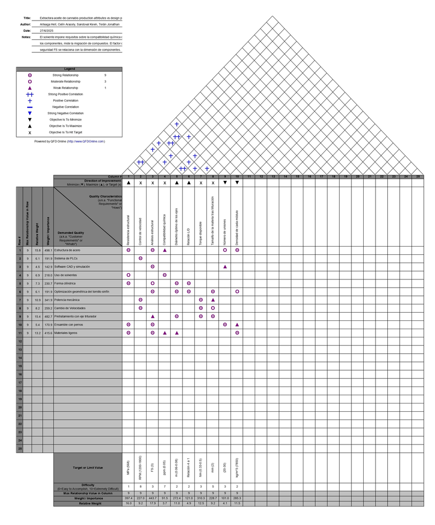

*Figura 3. Casa de calidad 3 (Atributos de producción vs Parametros de diseño).*

# 3 Descargar el archivo original

El siguiente enlace permite descargar el archivo Excel utilizado en este informe, el cual contiene toda la estructura desarrollada:

📥 Descargar archivo Excel de Casas de Calidad